# Analysis of HR Data

May 20th, 2017

## Human Resources

The work included in this presentation is based on a Datased from Kaggle https://www.kaggle.com by Ludovic Benistant, released under https://creativecommons.org/licenses/by-sa/4.0/ License.

The Dataset includes anonymised information on employees, including the following fields:

- Satisfaction Level,
- Last Evaluation
- Number of projects
- Average monthy hours
- Time spent in the company (years)
- Salary level (High, Medium, Low)

Data is included in the file "HR_comma_sep.csv" provided.

## Loading the data

We read the file into a data frame. Let's have a look

```r
library(ggplot2)
hr<- read.csv("HR_comma_sep.csv")
head(hr)
```

```
##   satisfaction_level last_evaluation number_project average_montly_hours
## 1               0.38            0.53              2                  157
## 2               0.80            0.86              5                  262
## 3               0.11            0.88              7                  272
## 4               0.72            0.87              5                  223
## 5               0.37            0.52              2                  159
## 6               0.41            0.50              2                  153
##   time_spend_company Work_accident left promotion_last_5years sales salary
## 1                  3             0    1                     0 sales    low
## 2                  6             0    1                     0 sales medium
## 3                  4             0    1                     0 sales medium
## 4                  5             0    1                     0 sales    low
## 5                  3             0    1                     0 sales    low
## 6                  3             0    1                     0 sales    low
```

In the Shiny presentation, we include an Slider for the user to select a number of employees to display: between 100 and 2000.

## Human Resources

What we want to explore is the relationship between worked hours and satisfaction of the employee using a shiny applicacion.

This application will allow the user to select a number of employees to be displayed in a plot showing the above mentioned relationship.

Using the slider, the user will visually check how the distribution evolves with the number of employees.

## Examples of the plot

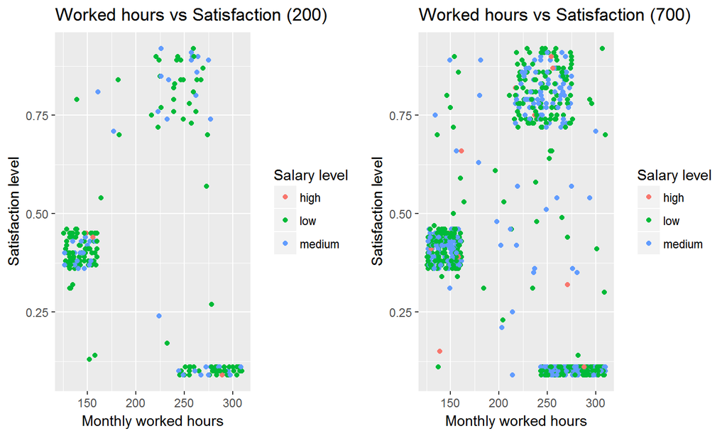